# Denetimli Makine Öğrenmesi Algoritmalarıyla Veri Analizi

MELİS MERVE DOGANCAY

4/8/2021

# Veri Seti:

$\bullet$ Çok değişkenli normal dağılım kullanılarak veri türetildi ve bu veri setinin üzerinden bazı denetimli makine öğrenmesi algoritmaları kullanılarak analizler yapıldı. Veri setinde 500 gözlem ve 9 değişken bulunmaktadır. Bağımlı değişken Y’dir.

```r
library(mvtnorm)
```

```r
set.seed(12)
sigma <- matrix(nrow = 8, ncol = 8, 0)
diag(sigma) = 1
mvn <- rmvnorm(n=500, mean=rnorm(8), sigma=sigma)
e=rnorm(500)
Y <- rowSums(mvn)+e
rmvm <- data.frame(cbind(Y, mvn))
names(rmvm) <- c("Y", paste("X", 1:8, sep = ""))


Y[Y>ceiling(mean(Y))]=1
Y[Y<=ceiling(mean(Y))]=0
Y
```

```
##   [1] 0 1 1 0 0 1 1 1 0 1 0 1 0 0 1 0 1 0 0 0 0 0 1 1 0 1 0 1 0 1 0 0 0 1 0
##  [36] 0 0 1 0 0 1 0 0 0 0 1 0 1 0 0 1 0 0 0 1 0 0 1 1 1 0 0 0 0 0 0 0 0 0 0
##  [71] 1 0 0 0 0 0 1 1 0 1 1 0 0 1 0 1 1 1 0 0 0 0 0 0 0 0 0 0 0 0 1 1 0 1 1
## [106] 0 0 0 1 1 1 0 0 0 0 0 0 0 0 0 1 1 1 0 0 1 0 1 0 0 0 0 0 0 0 0 1 0 1 1
## [141] 1 0 0 1 1 1 0 0 0 0 1 0 0 0 0 1 0 1 1 0 1 0 0 0 1 1 1 0 0 1 1 0 0 0 1
## [176] 1 0 1 0 0 0 1 1 0 1 0 0 0 0 0 0 0 0 1 0 0 0 1 0 1 1 0 1 1 1 1 0 0 0 1
## [211] 1 1 1 1 0 0 0 0 0 1 1 0 0 1 0 0 1 0 0 1 1 1 0 0 0 1 0 0 1 0 0 0 1 0 0
## [246] 1 1 1 0 1 0 1 0 1 0 0 0 0 1 0 1 0 0 1 0 1 0 0 0 0 1 0 0 0 0 0 0 0 1 1
## [281] 0 1 0 1 0 0 1 0 0 0 1 0 0 1 0 1 1 0 0 0 0 1 0 1 1 0 0 0 0 1 0 0 0 1 0
## [316] 0 1 0 1 0 1 0 1 1 1 0 0 0 0 0 1 0 0 1 0 1 0 0 0 1 1 1 0 1 0 0 1 0 1 0
## [351] 0 1 0 1 0 0 1 1 1 0 0 0 1 1 0 0 0 1 0 1 0 0 1 0 0 1 1 0 0 0 1 0 0 0 1
## [386] 0 1 0 0 0 0 0 0 1 0 0 0 0 1 0 0 0 0 1 0 1 1 1 1 0 0 1 1 1 0 0 1 0 0 0
## [421] 0 1 0 1 1 0 1 0 0 0 1 0 1 1 0 0 1 0 0 1 1 0 0 0 1 1 0 1 1 0 0 1 0 1 1
## [456] 0 0 1 0 0 1 0 0 0 0 0 1 1 1 0 0 0 1 1 1 0 0 1 0 0 1 0 1 1 0 0 1 0 1 0
## [491] 1 1 1 1 1 1 1 0 0 1
```

```r
rmvm[1] <- Y
```

```r
head(rmvm)
```

```
##   Y         X1        X2         X3         X4        X5          X6
## 1 0 -1.5870315 2.0051843 -1.7344641 -2.2138875 -2.777209 -0.26034429
## 2 1 -0.2916884 1.9176817 -0.4497763 -1.2133104 -1.774001  1.73490541
## 3 1 -2.5058124 1.3097846 -1.1558501 -0.7888827 -1.851842  0.08976868
## 4 0 -2.0215962 0.5066773 -1.3292012 -1.4051466 -1.722858 -0.75180861
## 5 0 -1.3755834 0.4211766 -0.3786099 -2.5156309 -2.306146  0.17716988
## 6 1 -0.7491142 1.0845704 -0.9994294 -1.0326758 -1.540815  1.74803880
##           X7         X8
## 1 -0.4677649 -1.3317195
## 2  0.6966304 -0.9307145
## 3  0.3586325  1.4437805
## 4  0.4827566 -1.6327064
## 5 -1.2924020 -0.4382574
## 6 -1.3662388  0.1063969
```

$\bullet$ Veri setinin %70’i eğitim ve %30’u test verisi olmak üzere ikiye ayrılmıştır. Eğitim seti üzerinde modeller kurulup, test seti ile de model başarısı değerlendirilmiştir.

```r
smp_size <- floor(0.70 * nrow(rmvm))
set.seed(123)
train_ind <- sample(nrow(rmvm), size = smp_size, replace = FALSE)
train <- rmvm[train_ind, ]
test <- rmvm[-train_ind, ]
dim(train)
```

```
## [1] 350   9
```

```r
dim(test)
```

```
## [1] 150   9
```

## 1.Eğitim verisi üzerinde sırasıyla

### a.sınıflandırma ağacı(CT)

### e.doğrusal ayırma analizi(LDA)

### f.eğrisel ayırma analizi(QDA)

## yöntemlerini uygulaması yapılmıştır.

## A.SINIFLANDIRMA AGACI(CT)

```r
library(tree)
```

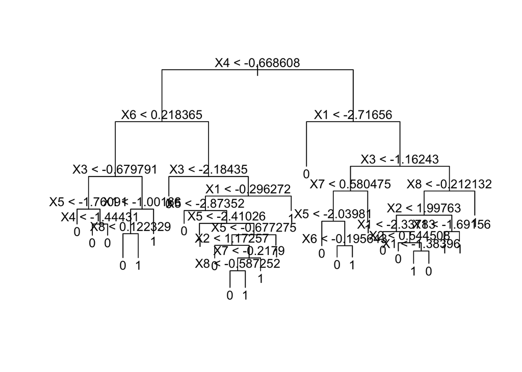

```r
tree.Y=tree(as.factor(Y)~., data=train)
plot(tree.Y)
text(tree.Y)
```

Şekilden de görüldüğü gibi sınıflandırma ağacı karmaşık bir yapıya sahiptir.Bazı düğüm noktalarının birleştirilebileceği gözlemlenmektedir.Bu yüzden de benzer düğüm noktaları için budama gereklidir.

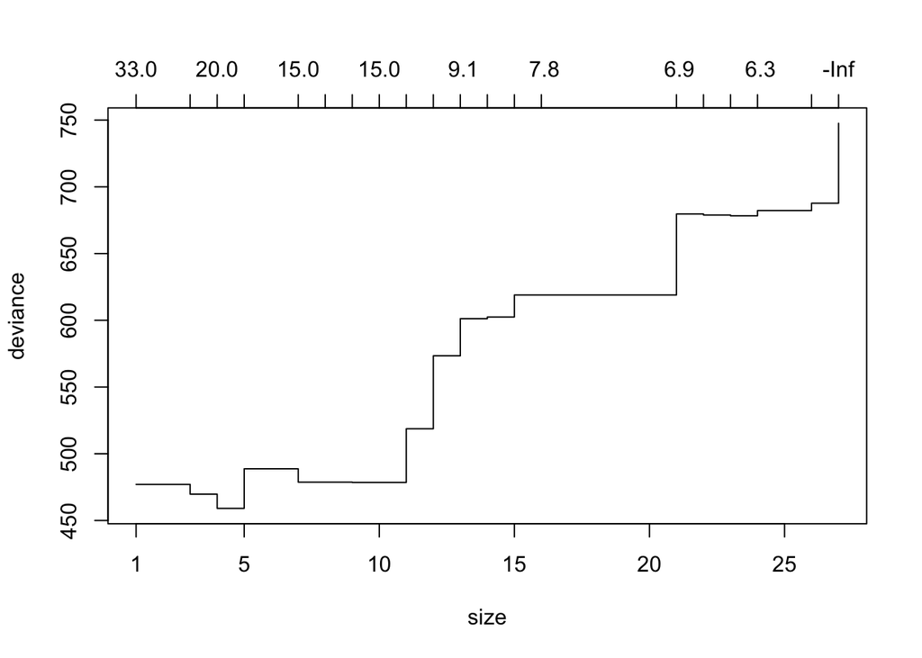

```r
cv=cv.tree(tree.Y)
plot(cv)
```

Ağacı budamak için budama noktasında çapraz doğrulama kullanılmıştır.Grafik incelenerek son düğüm noktası 4 olarak belirlenmiştir.

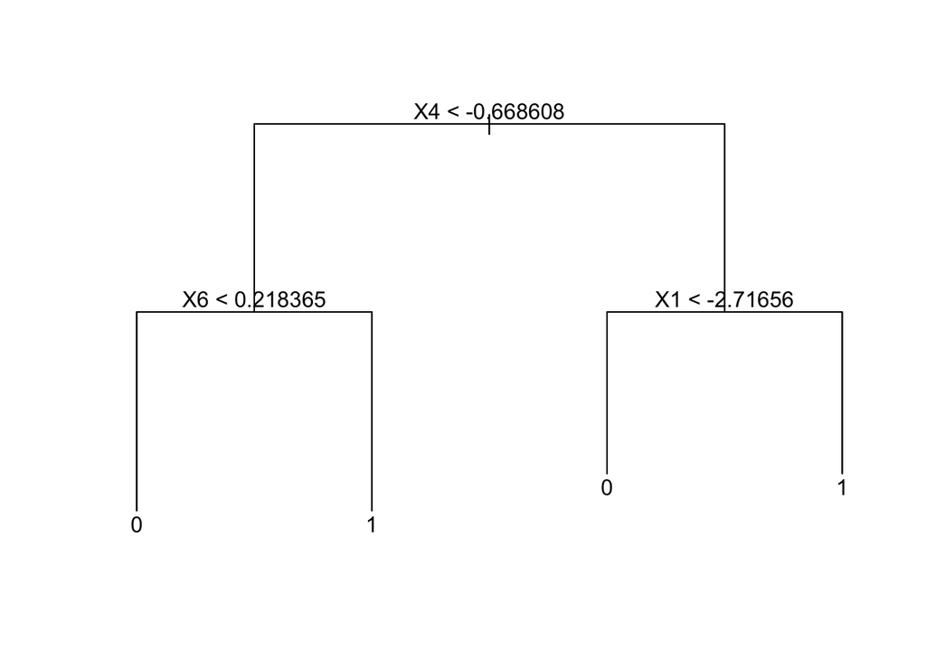

```r
prune.tree.Y=prune.tree(tree.Y, best=4)
plot(prune.tree.Y)
text(prune.tree.Y)
```

## B.BAGGING(Bag)

Bagging yönteminde tüm değişkenler kullanıldığından mtry 8 olarak belirlenmiştir.

```r
library(randomForest)
```

```r
bag.Y <- randomForest(as.factor(Y)~.,data = rmvm,subset = train_ind,mtry=8,importance=TRUE)
bag.Y
```

```
##
## Call:
##  randomForest(formula = as.factor(Y) ~ ., data = rmvm, mtry = 8,      importance = TRUE, subset = train_ind)
##                Type of random forest: classification
##                      Number of trees: 500
## No. of variables tried at each split: 8
##
##         OOB estimate of  error rate: 21.14%
## Confusion matrix:
##     0  1 class.error
## 0 188 29   0.1336406
## 1  45 88   0.3383459
```

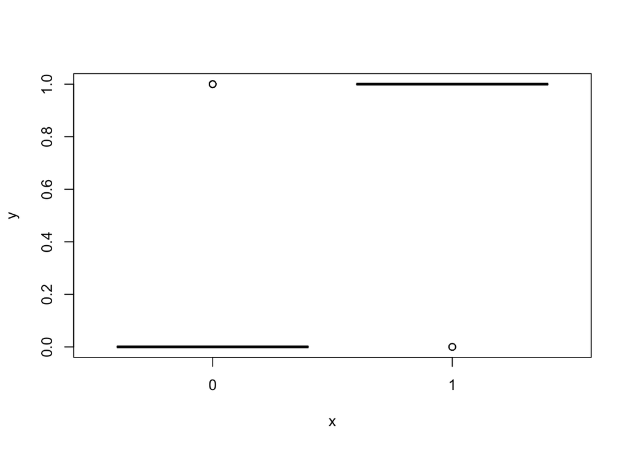

```r
yhat.bag<-predict(bag.Y,newdata=test)
plot(yhat.bag,test$Y)
```

```r
sqrt(mean((as.numeric(yhat.bag)-test$Y)^2))
```

```
## [1] 0.9899495
```

```r
bag.Y$importance
```

```
##              0          1 MeanDecreaseAccuracy MeanDecreaseGini
## X1 0.012485765 0.02748052          0.018032681         21.24481
## X2 0.006650085 0.01755899          0.010808305         16.85959
## X3 0.020616361 0.03928526          0.027582772         23.53037
## X4 0.025709456 0.04192120          0.031792558         23.98662
## X5 0.002536423 0.01088453          0.005552197         15.25636
## X6 0.018554420 0.03416225          0.024273241         22.63903
## X7 0.006979831 0.01184441          0.008795105         14.63668
## X8 0.027334112 0.04862328          0.035367396         26.36052
```

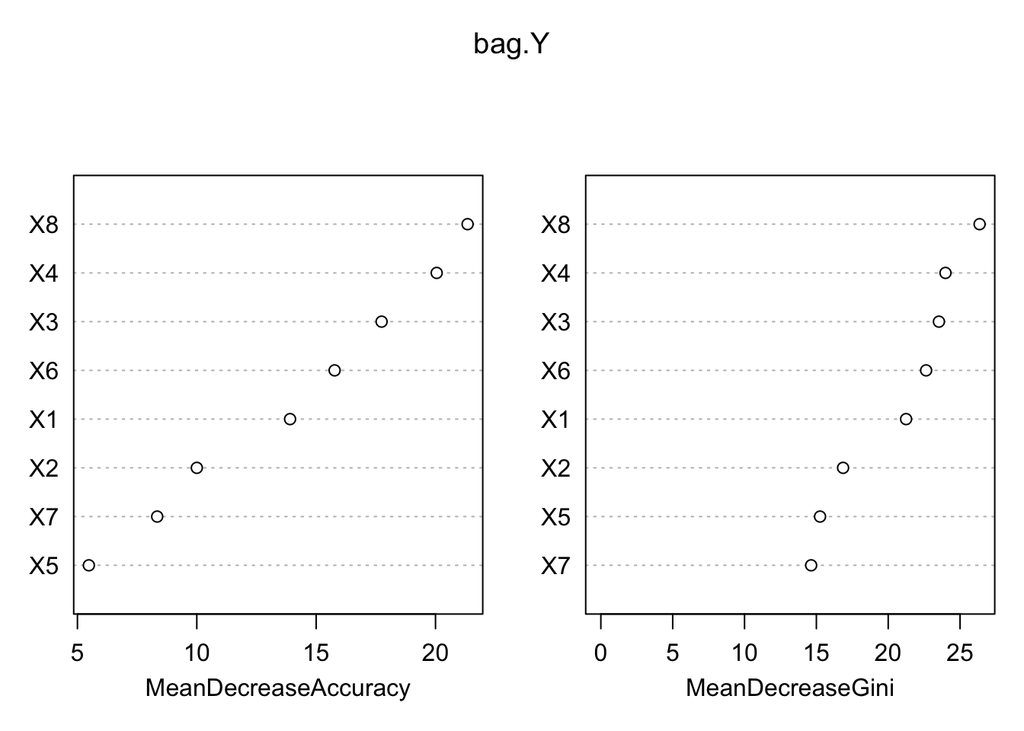

```r
varImpPlot(bag.Y)
```

Model için en önemli değişkenlerin X8 ve X4 olduğu görülmektedir.

## C.RANDOM FOREST(RF)

```r
set.seed(123)
bag.rf <- randomForest(as.factor(Y)~.,data = rmvm,subset = train_ind,mtry=3,importance=TRUE)
yhat.bag1<-predict(bag.rf,newdata=test)
sqrt(mean((as.numeric(yhat.bag1)-test$Y)^2))
```

```
## [1] 0.9865766
```

```r
bag.rf2 <- randomForest(as.factor(Y)~.,data = rmvm,subset = train_ind,mtry=4,importance=TRUE)
yhat.bag2<-predict(bag.rf2,newdata=test)
sqrt(mean((as.numeric(yhat.bag2)-test$Y)^2))
```

```
## [1] 0.9865766
```

```r
bag.rf3 <- randomForest(as.factor(Y)~.,data = rmvm,subset = train_ind,mtry=5,importance=TRUE)
yhat.bag3<-predict(bag.rf3,newdata=test)
sqrt(mean((as.numeric(yhat.bag3)-test$Y)^2))
```

```
## [1] 0.9831921
```

```r
importance(bag.rf)
```

```
##            0         1 MeanDecreaseAccuracy MeanDecreaseGini
## X1 10.415975 10.601621            13.662776         21.31943
## X2  3.313536  6.895173             7.135418         17.40968
## X3 11.902706 15.093207            18.194856         22.36733
## X4 15.439992 17.021207            22.068745         24.45476
## X5  2.178272  4.928848             4.759941         15.61635
## X6 11.882067 13.439380            16.513941         22.60501
## X7  6.923368  5.184707             8.197903         15.77831
## X8 16.405026 17.421883            22.908396         24.98711
```

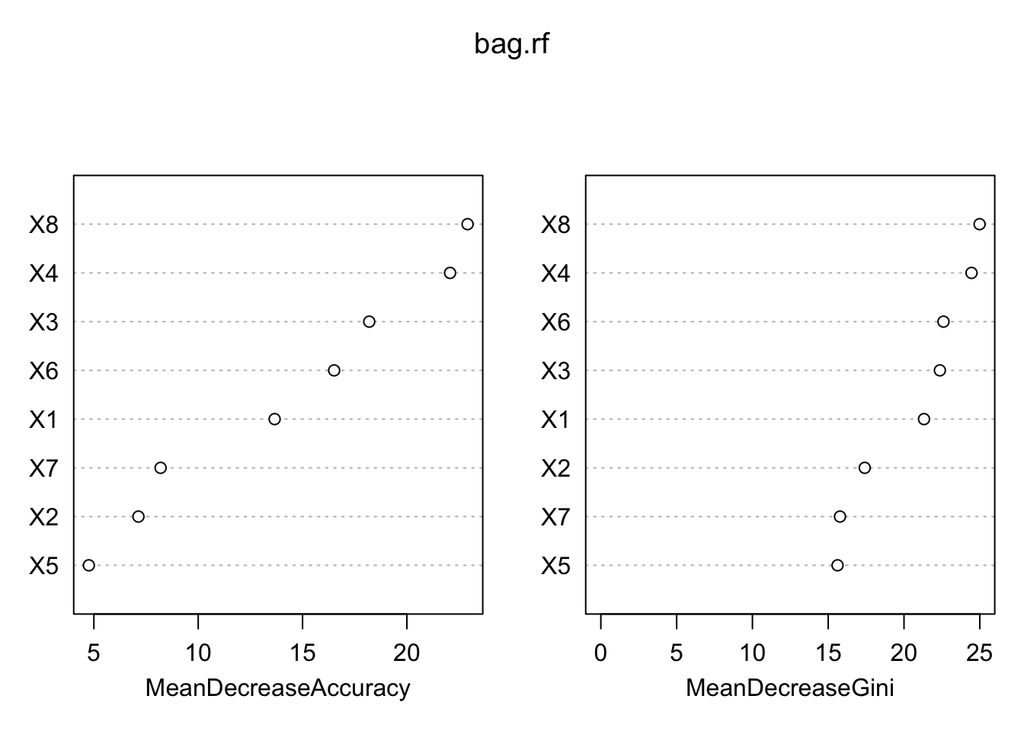

```r
varImpPlot(bag.rf)
```

Model için en önemli değişkenlerin X8 ve X4 olduğu görülmektedir.

## D.LOJISTIK REGRESYON(LR)

```r
logisticreg<-glm(Y~.,family=binomial, data=train)
summary(logisticreg)
```

```
##
## Call:
## glm(formula = Y ~ ., family = binomial, data = train)
##
## Deviance Residuals:
##      Min        1Q    Median        3Q       Max
## -2.60915  -0.39156  -0.05878   0.24909   2.50305
##
## Coefficients:
##             Estimate Std. Error z value Pr(>|z|)
## (Intercept)   5.7282     0.8709   6.578 4.78e-11 ***
## X1            1.5393     0.2599   5.922 3.18e-09 ***
## X2            1.6638     0.2784   5.976 2.29e-09 ***
## X3            1.4106     0.2522   5.594 2.22e-08 ***
## X4            1.8037     0.2845   6.340 2.30e-10 ***
## X5            1.4103     0.2400   5.877 4.17e-09 ***
## X6            1.3485     0.2226   6.058 1.38e-09 ***
## X7            1.2043     0.2319   5.193 2.07e-07 ***
## X8            1.6721     0.2455   6.812 9.63e-12 ***
## ---
## Signif. codes:  0 '***' 0.001 '**' 0.01 '*' 0.05 '.' 0.1 ' ' 1
##
## (Dispersion parameter for binomial family taken to be 1)
##
##     Null deviance: 464.84  on 349  degrees of freedom
## Residual deviance: 186.08  on 341  degrees of freedom
## AIC: 204.08
##
## Number of Fisher Scoring iterations: 7
```

```r
G=logisticreg$null.deviance-logisticreg$deviance
1-pchisq(G,8)
```

```
## [1] 0
```

Lojistik regresyon modelinde tüm katsayıların p değeri 0.05 den küçük olduğundan istatiksel olarak anlamlıdır.Aynı zamanda model geçerliliği de test edilmiştir ve model anlamlı çıkmıştır.(p=0<0.05 model anlamlıdır.)

## E.DOĞRUSAL AYIRMA ANALİZİ(LDA)

İlk olarak varsayım kontrolü yapıldı.

```r
library(mvnTest)
library(heplots)
library(MASS)
```

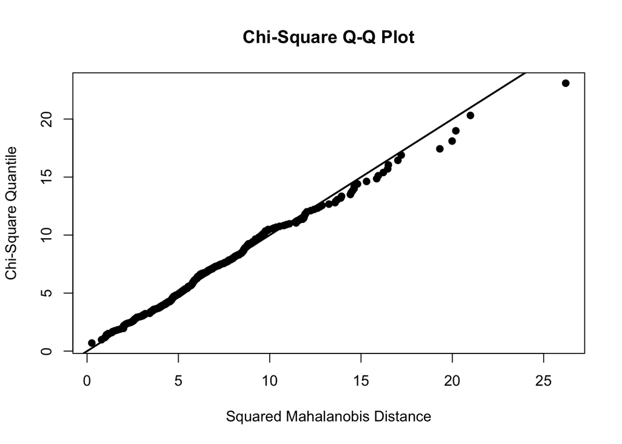

```r
Y0<- rmvm[rmvm$Y==0, 2:8]
res1 <- AD.test(Y0, qqplot = TRUE)
```

```r
res1
```

```
##             Anderson-Darling test for Multivariate Normality
##
##   data : Y0
##
##   AD              : 0.6393131
##   p-value         : 0.2935706
##
##   Result  : Data are multivariate normal (sig.level = 0.05)
```

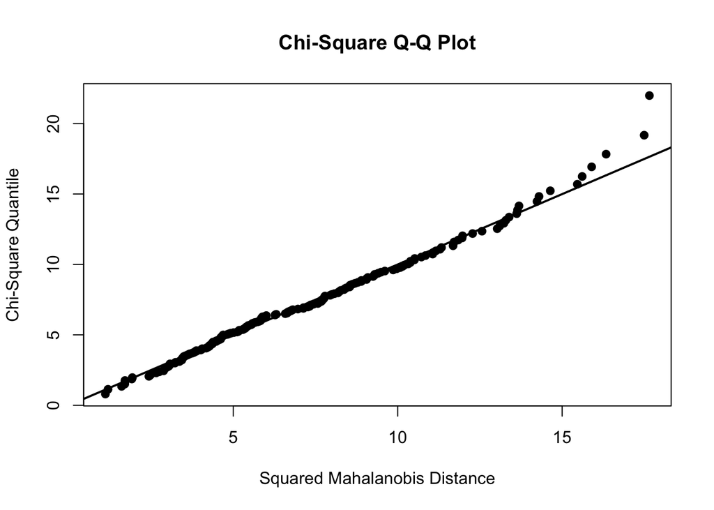

```r
Y1<- rmvm[rmvm$Y==1, 2:8]
res2 <- AD.test(Y1, qqplot = TRUE)
```

```r
res2
```

```
##             Anderson-Darling test for Multivariate Normality
##
##   data : Y1
##
##   AD              : 0.3905113
##   p-value         : 0.6320368
##
##   Result  : Data are multivariate normal (sig.level = 0.05)
```

```r
boxm <- heplots::boxM(rmvm[, c(2:8)], rmvm$Y)
boxm
```

```
##
##  Box's M-test for Homogeneity of Covariance Matrices
##
## data:  rmvm[, c(2:8)]
## Chi-Sq (approx.) = 39.559, df = 28, p-value = 0.07234
```

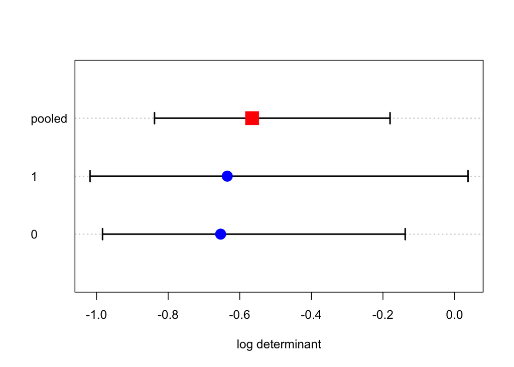

```r
plot(boxm)
```

Veri setimiz çoklu normal dağılım varsayımını sağlamaktadır.

boxm fonksiyonu homojenlik var mı yok mu hepsini bir arada gösteriyor. $H_{0}$’ın reddedilmesini istemiyoruz.

$H_{0}$ reddedemedik(p=0.07234>0.05).Homojen varyans kovaryans matrisimiz var.

LDA analizi varsayımlar sağlandığı için yapılabilir.

```r
model_lda<-lda(Y~.,data=train)
model_lda
```

```
## Call:
## lda(Y ~ ., data = train)
##
## Prior probabilities of groups:
##    0    1
## 0.62 0.38
##
## Group means:
##          X1       X2         X3        X4        X5         X6          X7
## 0 -1.674220 1.501610 -1.1378183 -1.156335 -2.221410 -0.4803005 -0.39695029
## 1 -1.112578 1.913769 -0.6005349 -0.556052 -1.810355  0.1004584 -0.04261304
##           X8
## 0 -0.8618644
## 1 -0.2537449
##
## Coefficients of linear discriminants:
##          LD1
## X1 0.5786184
## X2 0.4857811
## X3 0.5237012
## X4 0.6014753
## X5 0.4652765
## X6 0.4850813
## X7 0.4125571
## X8 0.6418548
```

```r
attributes(model_lda)
```

```
## $names
##  [1] "prior"   "counts"  "means"   "scaling" "lev"     "svd"     "N"
##  [8] "call"    "terms"   "xlevels"
##
## $class
## [1] "lda"
```

```r
model_lda$prior
```

```
##    0    1
## 0.62 0.38
```

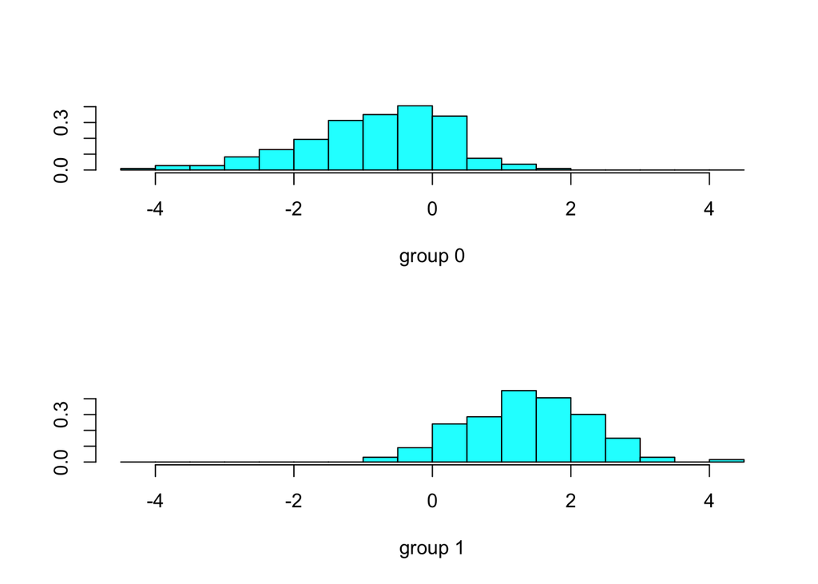

```r
tahmin_1<-predict(model_lda,train)
hist_lda1<-ldahist(data=tahmin_1$x[,1],g=train$Y)
```

## F.EĞRİSEL AYIRMA ANALİZİ(QDA)

LDA’da yapılan varsayım kontrolleri sağlandığı için QDA analizinde varsayım kontrolüne gerek yoktur.

```r
model_qda<-qda(Y~.,data=train)
model_qda
```

```
## Call:
## qda(Y ~ ., data = train)
##
## Prior probabilities of groups:
##    0    1
## 0.62 0.38
##
## Group means:
##          X1       X2         X3        X4        X5         X6          X7
## 0 -1.674220 1.501610 -1.1378183 -1.156335 -2.221410 -0.4803005 -0.39695029
## 1 -1.112578 1.913769 -0.6005349 -0.556052 -1.810355  0.1004584 -0.04261304
##           X8
## 0 -0.8618644
## 1 -0.2537449
```

## 2.Yöntemlere ait doğruluk(accuracy) değerini test verisi üzerinden elde edilmesi ve Doğruluk değerlerine göre en uygun yöntemi belirlenmesi:

$\bullet$ Classification Tree:

```r
tree.pred=predict(prune.tree.Y,newdata=test,type="class")
xtab.Y.tree=table(tree.pred,test$Y)
accuracy_tree_2<-sum(diag(xtab.Y.tree))/sum(xtab.Y.tree)
accuracy_tree_2
```

```
## [1] 0.6266667
```

$\bullet$ Bagging:

```r
tahmin_BAG<-predict(bag.Y,test)
cfmatrix_BAG<-table(Tahmin=tahmin_BAG, Gercek=test$Y)
cfmatrix_BAG
```

```
##       Gercek
## Tahmin  0  1
##      0 82 18
##      1  5 45
```

```r
accuracy_BAG<-sum(diag(cfmatrix_BAG))/sum(cfmatrix_BAG)
accuracy_BAG
```

```
## [1] 0.8466667
```

$\bullet$ Random Forest:

```r
tahmin_bag.rf<-predict(bag.rf,test)
cfmatrix_bag.rf<-table(Tahmin=tahmin_bag.rf, Gercek=test$Y)
cfmatrix_bag.rf
```

```
##       Gercek
## Tahmin  0  1
##      0 83 16
##      1  4 47
```

```r
accuracy_bag.rf<-sum(diag(cfmatrix_bag.rf))/sum(cfmatrix_bag.rf)
accuracy_bag.rf
```

```
## [1] 0.8666667
```

$\bullet$ Lojistik Regresyon:

```r
p.tahmin.Y2<-predict(logisticreg, newdata=test,type="response")
p.tahmin.Y2[p.tahmin.Y2>mean(Y)]=1
p.tahmin.Y2[p.tahmin.Y2<=mean(Y)]=0

xtab.Y2=table(p.tahmin.Y2,test$Y)
accuracy_log_2<-sum(diag(xtab.Y2))/sum(xtab.Y2)
accuracy_log_2
```

```
## [1] 0.9533333
```

$\bullet$ LDA:

```r
tahmin_2<-predict(model_lda,test)
tahmin_2$class
```

```
##   [1] 0 1 1 1 0 0 1 1 0 0 0 0 0 1 0 1 0 0 0 0 1 1 1 0 0 0 0 1 0 0 1 0 0 0 0
##  [36] 1 0 0 0 0 1 0 1 1 0 0 0 1 0 0 0 0 0 1 0 0 1 0 1 0 0 0 1 0 0 0 0 0 1 1
##  [71] 0 0 0 1 0 0 1 1 1 1 0 1 0 1 0 0 0 0 0 0 0 0 1 1 1 0 0 1 1 0 0 1 0 1 1
## [106] 1 0 0 0 0 1 0 0 1 1 0 1 1 1 0 0 0 0 0 1 0 0 1 0 1 1 1 1 0 1 0 0 0 1 0
## [141] 0 0 1 1 1 0 1 0 0 1
## Levels: 0 1
```

```r
cfmatrix_2<-table(Tahmin=tahmin_2$class, Gercek=test$Y)
cfmatrix_2
```

```
##       Gercek
## Tahmin  0  1
##      0 85  7
##      1  2 56
```

```r
accuracy_2<-sum(diag(cfmatrix_2))/sum(cfmatrix_2)
accuracy_2
```

```
## [1] 0.94
```

$\bullet$ QDA:

```r
tahmin_qda_2<-predict(model_qda,test)
cfmatrix_qda_2<-table(Tahmin=tahmin_qda_2$class, Gercek=test$Y)
accuracy_qda_2<-mean(tahmin_qda_2$class==test$Y)
accuracy_qda_2
```

```
## [1] 0.9466667
```

Accuracy değerlerine bakıldğında lojistik regresyon yönteminin en doğru yöntem olduğu belirlenmiştir. (LR=0.95>QDA=0.946>LDA=0.94>RF=0.86>Bag=0.84>CT=0.62)

## 3.Tüm modellere ait ROC eğrisinin tek bir grafik üstünde gösterimi ve eğri altında kalan(AUC) hesaplaması yaparak bu değere göre en uygun modele karar verilmesi:

```r
library(ROCR)
```

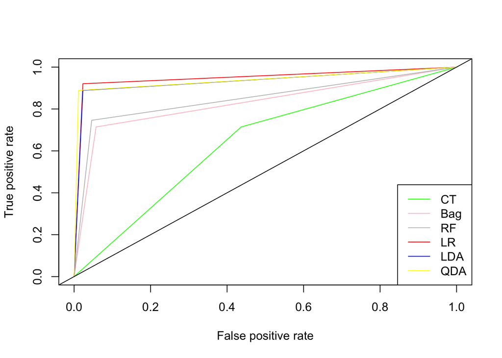

```r
tahmin=as.numeric(tree.pred)
tahmin=ifelse(tahmin<=1,0,1)
pr.tree <- prediction(tahmin, test$Y)
prf.tree<- performance(pr.tree, measure = "tpr", x.measure = "fpr")
plot(prf.tree, col="green")

tahmin=as.numeric(yhat.bag)
tahmin=ifelse(tahmin<=1,0,1)
pr.bag <- prediction(tahmin, test$Y)
prf.bag<- performance(pr.bag, measure = "tpr", x.measure = "fpr")
plot(prf.bag, col="pink", add=TRUE)

tahmin=as.numeric(yhat.bag1)
tahmin=ifelse(tahmin<=1,0,1)
pr.bag.rf <- prediction(tahmin, test$Y)
prf.bag.rf<- performance(pr.bag.rf, measure = "tpr", x.measure = "fpr")
plot(prf.bag.rf, col="gray", add=TRUE)

pr.log <- prediction(p.tahmin.Y2, test$Y)
prf.log <- performance(pr.log, measure = "tpr", x.measure = "fpr")
plot(prf.log, col="red", add=TRUE)

tahmin=as.numeric(tahmin_2$class)
tahmin=ifelse(tahmin<=1,0,1)
pr.lda <- prediction(tahmin, test$Y)
prf.lda <- performance(pr.lda, measure = "tpr", x.measure = "fpr")
plot(prf.lda, add=TRUE, col="blue")

tahmin=as.numeric(tahmin_qda_2$class)
tahmin=ifelse(tahmin<=1,0,1)
pr.qda <- prediction(tahmin, test$Y)
prf.qda <- performance(pr.qda, measure = "tpr", x.measure = "fpr")
plot(prf.qda, add=TRUE, col="yellow")
abline(0,1)

legend("bottomright",legend=c("CT","Bag","RF","LR","LDA","QDA"),lty=c(1,1,1,1,1,1),
       col=c("green","pink","gray","red","blue","yellow"))
```

```r
auc.log <- performance(pr.log, measure = "auc")
auc.log <- auc.log@y.values[[1]]
auc.log
```

```
## [1] 0.9488232
```

```r
auc.lda <- performance(pr.lda, measure = "auc")
auc.lda <- auc.lda@y.values[[1]]
auc.lda
```

```
## [1] 0.9329502
```

```r
auc.tree <- performance(pr.tree, measure = "auc")
auc.tree <- auc.tree@y.values[[1]]
auc.tree
```

```
## [1] 0.6387521
```

```r
auc.qda <- performance(pr.qda, measure = "auc")
auc.qda <- auc.qda@y.values[[1]]
auc.qda
```

```
## [1] 0.9386973
```

```r
auc.bag <- performance(pr.bag, measure = "auc")
auc.bag <- auc.bag@y.values[[1]]
auc.bag
```

```
## [1] 0.8284072
```

```r
auc.bag.rf <- performance(pr.bag.rf, measure = "auc")
auc.bag.rf <- auc.bag.rf@y.values[[1]]
auc.bag.rf
```

```
## [1] 0.8500274
```

Eğri altında kalan(AUC) değerlerine göre de en uygun modelin lojistik regresyon ile elde edilen logisticreg modeli olduğu belirlenmiştir.(LR=0.94>QDA=0.938>LDA=0.932>RF=0.85>Bag=0.82>CT=0.63)